# FINAL NOTEBOOK

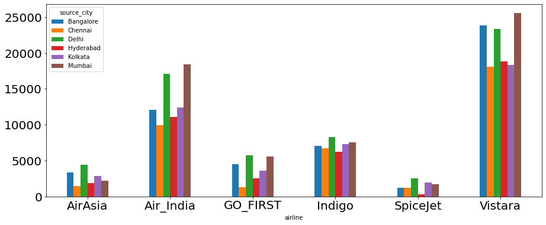

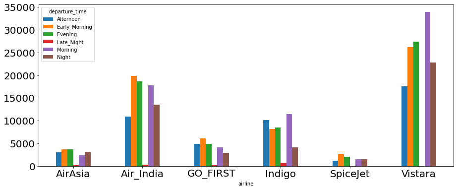

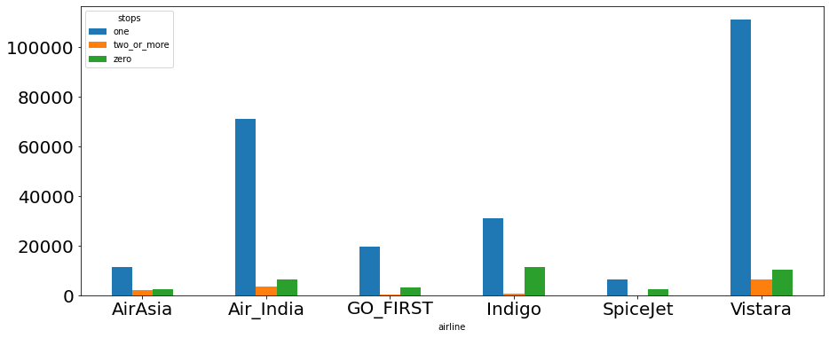

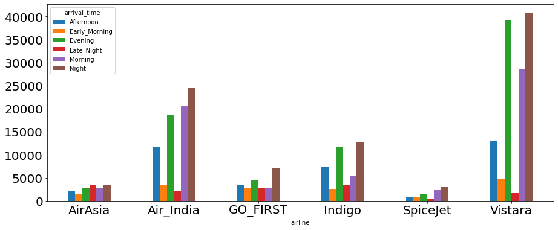

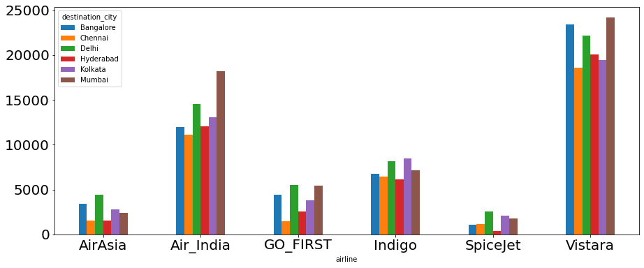

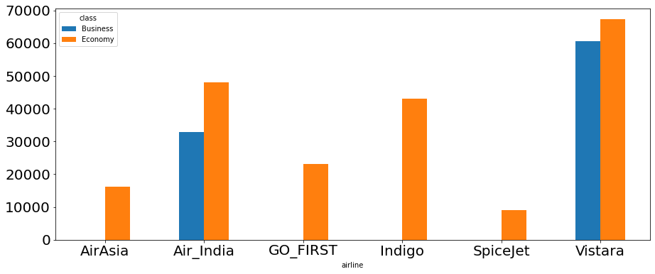

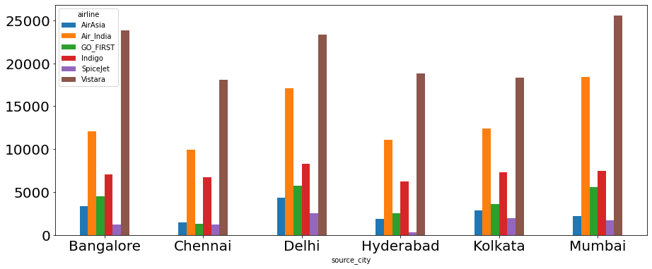

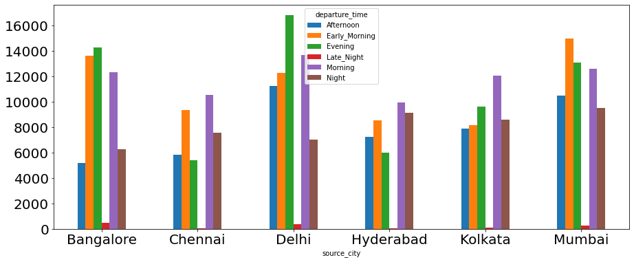

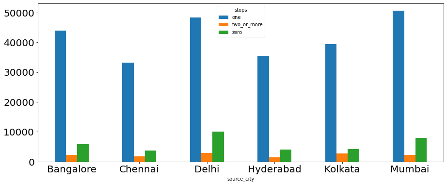

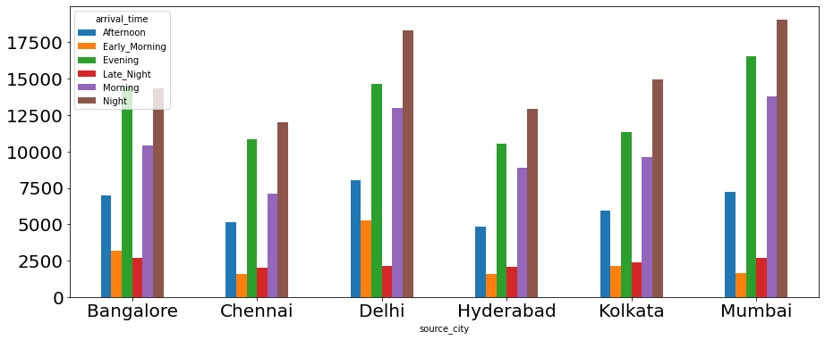

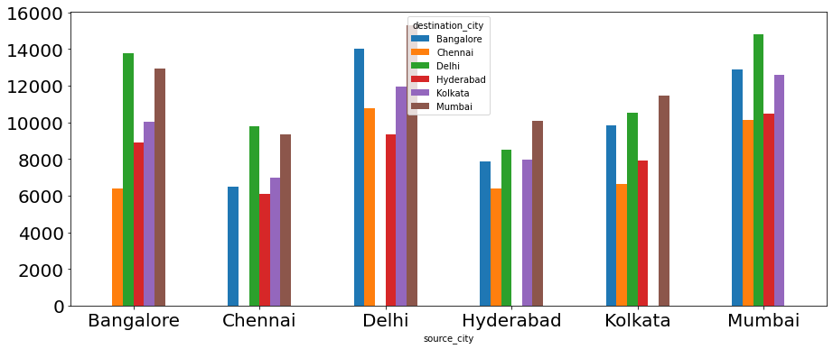

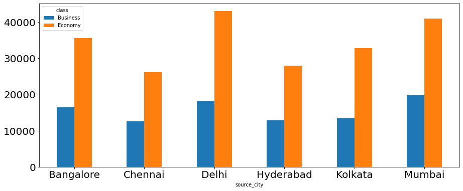

[30 more figures not shown]

```python
#cat vs cat

for i in cat1:
    for j in cat1:
        if i not in j:
            pd.crosstab(df[i], df[j]).plot(kind="bar", fontsize=20)
            #plt.title(i, "Vs", j, fontsize=20)
            plt.xticks(rotation=0)
            plt.show()
```

```python
num1=num.drop("price")
num1
```

```
Index(['duration', 'days_left'], dtype='object')
```

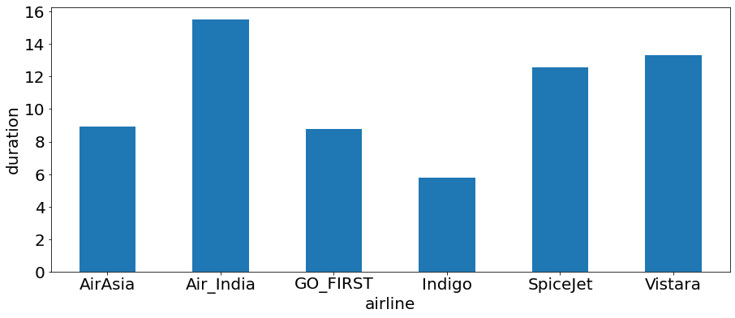

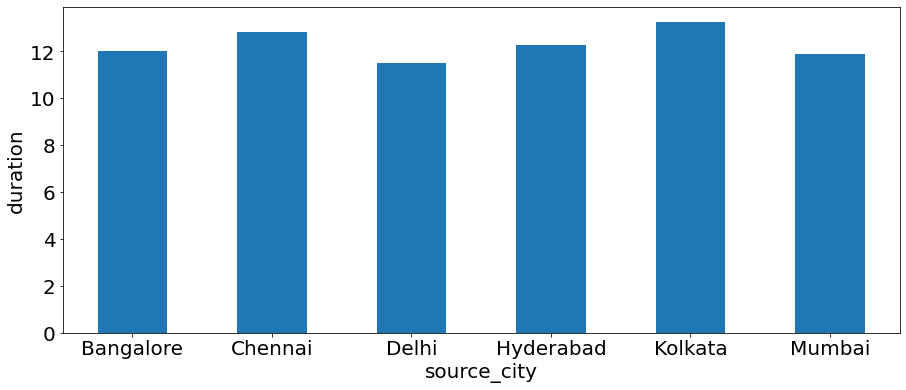

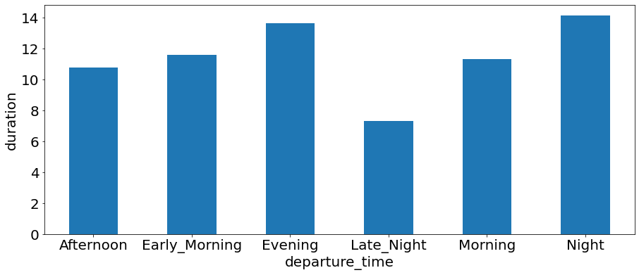

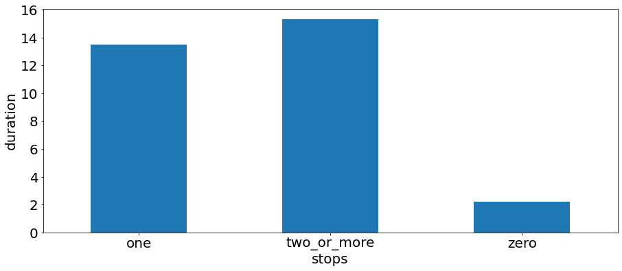

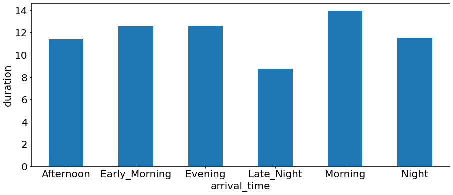

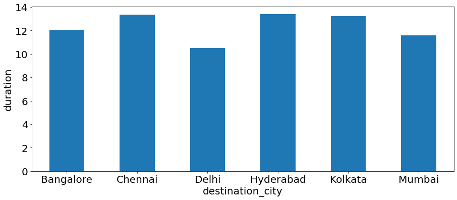

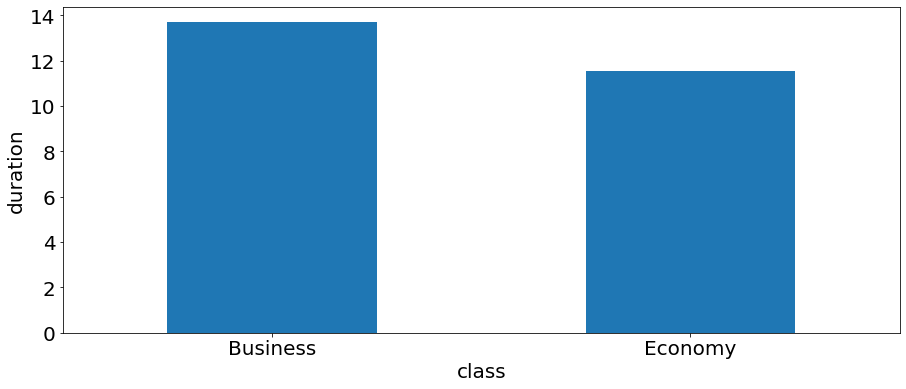

```python
#cat vs numerical

for j in cat1:
    df.groupby(j)["duration"].mean().plot(kind="bar", fontsize=20)
    plt.xlabel(j, fontsize=20)
    plt.ylabel("duration", fontsize=20)
    plt.xticks(rotation=0)
    plt.show()
```

```python
col=fp.columns.drop(["price","days_left","duration",'flight'])
col
```

```
Index(['airline', 'source_city', 'departure_time', 'stops', 'arrival_time',
       'destination_city', 'class'],
      dtype='object')
```

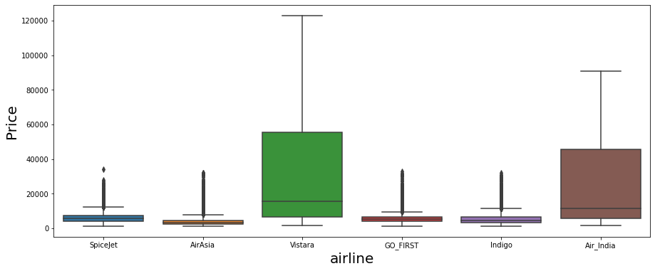

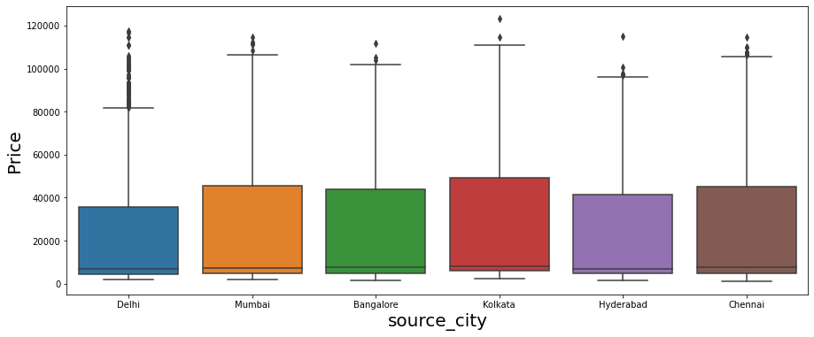

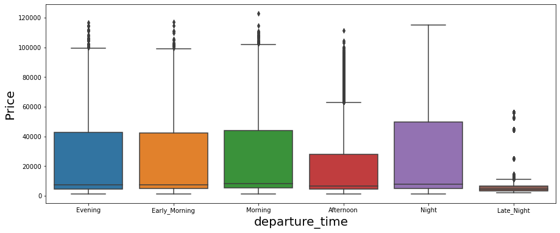

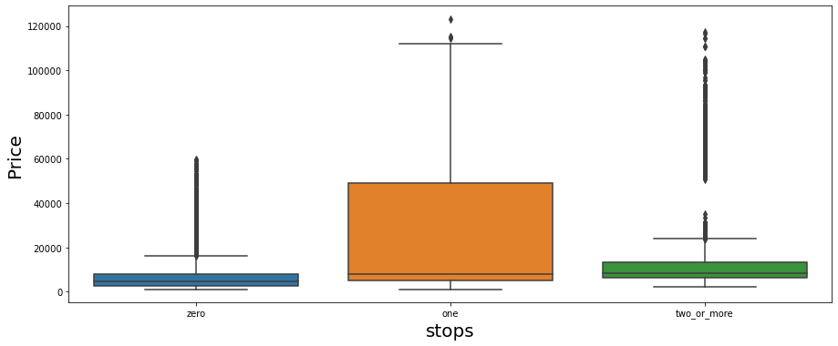

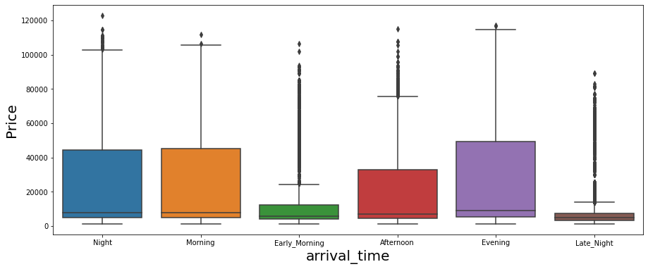

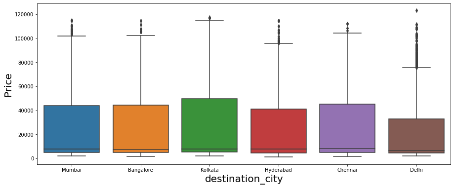

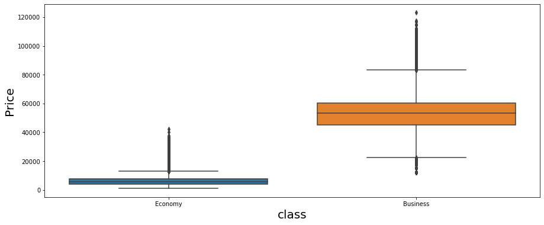

```python
#cat vs target

for i in col:
    sns.boxplot(fp[i], df["price"])
    plt.xlabel(i, fontsize=20)
    plt.ylabel("Price", fontsize=20)
    plt.xticks(rotation=0)
    plt.show()
    plt.show()
```

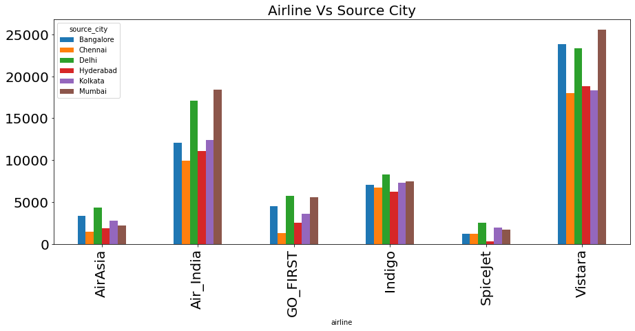

```python
pd.crosstab(fp["airline"],fp["source_city"]).plot(kind="bar", fontsize=20)
plt.title("Airline Vs Source City", fontsize=20)
```

```python
df.head()
```

|  | airline | source_city | departure_time | stops | arrival_time | destination_city | class | duration | days_left | price |
| --- | --- | --- | --- | --- | --- | --- | --- | --- | --- | --- |
| 0 | SpiceJet | Delhi | Evening | zero | Night | Mumbai | Economy | 2.17 | 1 | 5953 |
| 1 | SpiceJet | Delhi | Early_Morning | zero | Morning | Mumbai | Economy | 2.33 | 1 | 5953 |
| 2 | AirAsia | Delhi | Early_Morning | zero | Early_Morning | Mumbai | Economy | 2.17 | 1 | 5956 |
| 3 | Vistara | Delhi | Morning | zero | Afternoon | Mumbai | Economy | 2.25 | 1 | 5955 |
| 4 | Vistara | Delhi | Morning | zero | Morning | Mumbai | Economy | 2.33 | 1 | 5955 |

```python
df_new=pd.get_dummies(df)
```

```python
df_new.shape
```

```
(300153, 38)
```

```python
x=df_new.drop('price',axis=1)
y=df_new.price
```

```python
from sklearn.model_selection import train_test_split
```

```python
xtrain,xtest,ytrain,ytest=train_test_split(x,y,test_size=0.2,random_state=2406)
```

# Decision Tree Regressor

```python
from sklearn.tree import DecisionTreeRegressor
```

```python
from sklearn.metrics import mean_squared_error,r2_score
```

```python
dt=DecisionTreeRegressor()
```

```python
model=dt.fit(xtrain,ytrain)
```

```python
pred=model.predict(xtest)
```

```python
pred_tr=model.predict(xtrain)
```

```python
model.score(xtrain,ytrain)
```

```
0.9992864761272264
```

```python
model.score(xtest,ytest)
```

```
0.9765941544962006
```

```python
np.sqrt(mean_squared_error(ytest,pred))
```

```
3477.918017887609
```

```python
np.sqrt(mean_squared_error(ytrain,pred_tr))
```

```
606.062001758196
```

```python
r2_score(ytest,pred)
```

```
0.9765941544962006
```

```python
r2_score(ytrain,pred_tr)
```

```
0.9992864761272264
```

```python
from sklearn.metrics import mean_absolute_error,mean_absolute_percentage_error
```

```python
mean_absolute_error(ytest,pred)
```

```
1155.1123502856858
```

```python
mean_absolute_error(ytrain,pred_tr)
```

```
58.37608660042255
```

```python
mean_absolute_percentage_error(ytest,pred)
```

```
0.07352238755266621
```

```python
mean_absolute_percentage_error(ytrain,pred_tr)
```

```
0.002715213247545063
```

# Statsmodel

```python
import statsmodels.api as sma
```

```python
model=sma.OLS(ytrain,xtrain).fit()
```

```python
model.summary()
```

OLS Regression Results

| Dep. Variable: | price | R-squared: | 0.912 |
| --- | --- | --- | --- |
| Model: | OLS | Adj. R-squared: | 0.912 |
| Method: | Least Squares | F-statistic: | 8.275e+04 |
| Date: | Thu, 22 Dec 2022 | Prob (F-statistic): | 0.00 |
| Time: | 10:32:17 | Log-Likelihood: | -2.4575e+06 |
| No. Observations: | 240122 | AIC: | 4.915e+06 |
| Df Residuals: | 240091 | BIC: | 4.915e+06 |
| Df Model: | 30 |  |  |
| Covariance Type: | nonrobust |  |  |

|  | coef | std err | t | P>\|t\| | [0.025 | 0.975] |
| --- | --- | --- | --- | --- | --- | --- |
| duration | 41.8744 | 2.612 | 16.031 | 0.000 | 36.755 | 46.994 |
| days_left | -130.7899 | 1.017 | -128.623 | 0.000 | -132.783 | -128.797 |
| airline_AirAsia | 1339.4610 | 54.643 | 24.513 | 0.000 | 1232.362 | 1446.560 |
| airline_Air_India | 1475.7362 | 33.391 | 44.196 | 0.000 | 1410.291 | 1541.182 |
| airline_GO_FIRST | 3054.2182 | 46.682 | 65.426 | 0.000 | 2962.722 | 3145.714 |
| airline_Indigo | 3442.0475 | 37.867 | 90.897 | 0.000 | 3367.828 | 3516.267 |
| airline_SpiceJet | 3651.2503 | 70.624 | 51.700 | 0.000 | 3512.829 | 3789.672 |
| airline_Vistara | 5408.4555 | 29.832 | 181.297 | 0.000 | 5349.986 | 5466.926 |
| source_city_Bangalore | 3340.2927 | 31.737 | 105.250 | 0.000 | 3278.089 | 3402.496 |
| source_city_Chennai | 3299.6680 | 35.926 | 91.845 | 0.000 | 3229.253 | 3370.083 |
| source_city_Delhi | 1944.6151 | 29.998 | 64.824 | 0.000 | 1885.819 | 2003.411 |
| source_city_Hyderabad | 1689.2237 | 35.140 | 48.071 | 0.000 | 1620.350 | 1758.098 |
| source_city_Kolkata | 4945.0156 | 33.324 | 148.390 | 0.000 | 4879.700 | 5010.331 |
| source_city_Mumbai | 3152.3536 | 30.065 | 104.851 | 0.000 | 3093.427 | 3211.281 |
| departure_time_Afternoon | 2225.7496 | 44.605 | 49.899 | 0.000 | 2138.325 | 2313.174 |
| departure_time_Early_Morning | 3078.7061 | 41.531 | 74.131 | 0.000 | 2997.307 | 3160.105 |
| departure_time_Evening | 3000.4199 | 42.061 | 71.335 | 0.000 | 2917.982 | 3082.858 |
| departure_time_Late_Night | 4024.6138 | 176.969 | 22.742 | 0.000 | 3677.758 | 4371.469 |
| departure_time_Morning | 3101.4527 | 41.444 | 74.834 | 0.000 | 3020.223 | 3182.682 |
| departure_time_Night | 2940.2266 | 44.953 | 65.407 | 0.000 | 2852.120 | 3028.334 |
| stops_one | 7942.7161 | 28.441 | 279.266 | 0.000 | 7886.972 | 7998.461 |
| stops_two_or_more | 1.003e+04 | 54.830 | 182.903 | 0.000 | 9921.136 | 1.01e+04 |
| stops_zero | 399.8517 | 39.135 | 10.217 | 0.000 | 323.147 | 476.556 |
| arrival_time_Afternoon | 2612.8997 | 37.588 | 69.514 | 0.000 | 2539.229 | 2686.571 |
| arrival_time_Early_Morning | 1810.6562 | 54.769 | 33.060 | 0.000 | 1703.311 | 1918.002 |
| arrival_time_Evening | 3533.9107 | 29.805 | 118.566 | 0.000 | 3475.493 | 3592.329 |
| arrival_time_Late_Night | 3557.2291 | 58.668 | 60.634 | 0.000 | 3442.242 | 3672.216 |
| arrival_time_Morning | 3078.5614 | 31.751 | 96.958 | 0.000 | 3016.329 | 3140.793 |
| arrival_time_Night | 3777.9116 | 27.889 | 135.463 | 0.000 | 3723.250 | 3832.573 |
| destination_city_Bangalore | 3400.2965 | 31.915 | 106.541 | 0.000 | 3337.743 | 3462.850 |
| destination_city_Chennai | 3216.1600 | 35.333 | 91.024 | 0.000 | 3146.908 | 3285.412 |
| destination_city_Delhi | 1887.6692 | 31.183 | 60.535 | 0.000 | 1826.551 | 1948.788 |
| destination_city_Hyderabad | 1667.2406 | 34.636 | 48.136 | 0.000 | 1599.355 | 1735.127 |
| destination_city_Kolkata | 4814.0934 | 32.556 | 147.870 | 0.000 | 4750.284 | 4877.903 |
| destination_city_Mumbai | 3385.7091 | 30.590 | 110.680 | 0.000 | 3325.753 | 3445.665 |
| class_Business | 3.165e+04 | 27.276 | 1160.331 | 0.000 | 3.16e+04 | 3.17e+04 |
| class_Economy | -1.328e+04 | 21.855 | -607.537 | 0.000 | -1.33e+04 | -1.32e+04 |

| Omnibus: | 31305.232 | Durbin-Watson: | 2.004 |
| --- | --- | --- | --- |
| Prob(Omnibus): | 0.000 | Jarque-Bera (JB): | 268383.527 |
| Skew: | 0.344 | Prob(JB): | 0.00 |
| Kurtosis: | 8.133 | Cond. No. | 1.42e+16 |

Notes:  
[1] Standard Errors assume that the covariance matrix of the errors is correctly specified.  
[2] The smallest eigenvalue is 1.18e-24. This might indicate that there are  
strong multicollinearity problems or that the design matrix is singular.

```python
model.aic
```

```
4915076.598246571
```

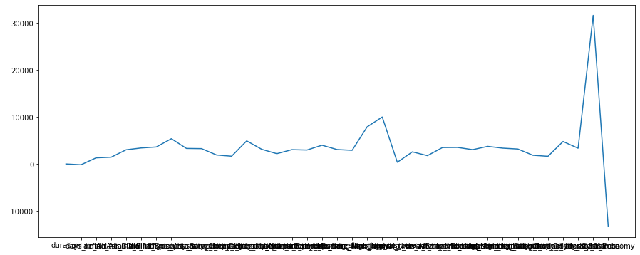

```python
plt.plot(model.params)
```

```python
import matplotlib.pyplot as plt
```

```python
from scipy import stats
```

```python
stats.jarque_bera(model.resid)
```

```
Jarque_beraResult(statistic=268383.52745072806, pvalue=0.0)
```

```python
#h0:Residuals are normally distributed

#ha:Residuals are not normally distributed

stats.jarque_bera(model.resid)
```

```
Jarque_beraResult(statistic=268383.52745072806, pvalue=0.0)
```

```python
#to check auto correlation

from statsmodels.stats.stattools import durbin_watson

durbin_watson(model.resid)
```

```
2.0035093726916173
```

```python
#multicollinearity
```

```python
#linearity
sma.stats.linear_rainbow(model)
```

```
(1.0046979938803238, 0.2084065893034302)
```

```python
#heteroscadasticity
import statsmodels.stats.api as ssa
```

```python
ssa.het_breuschpagan(model.resid,model.model.exog)
```

```
(48230.41116308398, 0.0, 2011.4982139554659, 0.0)
```

```python
# Multicollinearity:
from statsmodels.stats.outliers_influence import variance_inflation_factor
```

```python
nu=fp.select_dtypes(include=np.number)
```

```python
vif_list=[]
for x in range(nu.shape[1]):
    vif_list.append(variance_inflation_factor(nu.values,x))
```

```python
v=pd.DataFrame(vif_list,index=nu.columns)
```

```python
v
```

|  | 0 |
| --- | --- |
| duration | 2.843695 |
| days_left | 2.374938 |
| price | 1.808694 |

```python
from sklearn.ensemble import AdaBoostRegressor
```

```python
ada=AdaBoostRegressor()
```

```python
ada.fit(xtrain,ytrain)
```

```
AdaBoostRegressor()
```

```python
pred_ada=ada.predict(xtest)
```

```python
from sklearn.metrics import r2_score
```

```python
r2_score(ytest,pred_ada)
```

```
0.927984250515565
```

```python
import numpy as np
```

```python
import matplotlib.pyplot as plt
```

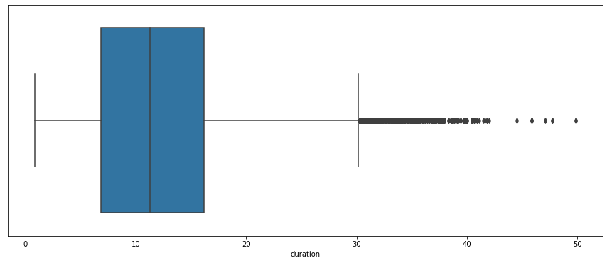

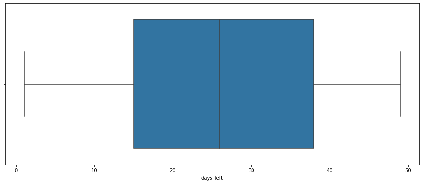

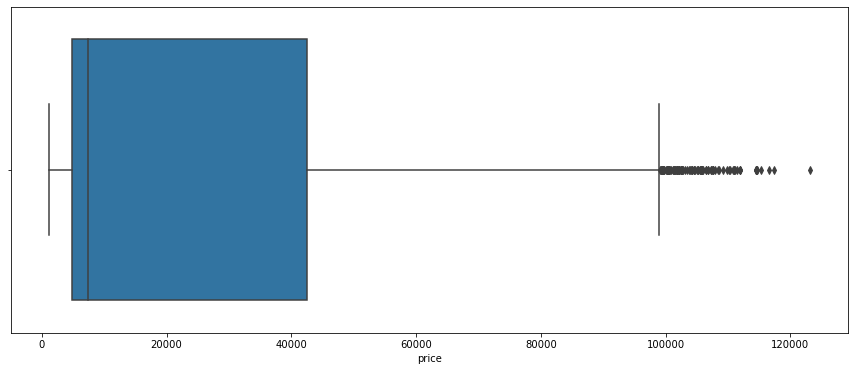

```python
#outliers
for x in  nu:
    sns.boxplot(nu[x])
    plt.show()
```

```python
fp
```

|  | airline | flight | source_city | departure_time | stops | arrival_time | destination_city | class | duration | days_left | price |
| --- | --- | --- | --- | --- | --- | --- | --- | --- | --- | --- | --- |
| 0 | SpiceJet | SG-8709 | Delhi | Evening | zero | Night | Mumbai | Economy | 2.17 | 1 | 5953 |
| 1 | SpiceJet | SG-8157 | Delhi | Early_Morning | zero | Morning | Mumbai | Economy | 2.33 | 1 | 5953 |
| 2 | AirAsia | I5-764 | Delhi | Early_Morning | zero | Early_Morning | Mumbai | Economy | 2.17 | 1 | 5956 |
| 3 | Vistara | UK-995 | Delhi | Morning | zero | Afternoon | Mumbai | Economy | 2.25 | 1 | 5955 |
| 4 | Vistara | UK-963 | Delhi | Morning | zero | Morning | Mumbai | Economy | 2.33 | 1 | 5955 |
| ... | ... | ... | ... | ... | ... | ... | ... | ... | ... | ... | ... |
| 300148 | Vistara | UK-822 | Chennai | Morning | one | Evening | Hyderabad | Business | 10.08 | 49 | 69265 |
| 300149 | Vistara | UK-826 | Chennai | Afternoon | one | Night | Hyderabad | Business | 10.42 | 49 | 77105 |
| 300150 | Vistara | UK-832 | Chennai | Early_Morning | one | Night | Hyderabad | Business | 13.83 | 49 | 79099 |
| 300151 | Vistara | UK-828 | Chennai | Early_Morning | one | Evening | Hyderabad | Business | 10.00 | 49 | 81585 |
| 300152 | Vistara | UK-822 | Chennai | Morning | one | Evening | Hyderabad | Business | 10.08 | 49 | 81585 |

300153 rows × 11 columns

```python
def day(x):
    if x <10:
        return('less than 10 days')
    elif x<20:
        return('less than 20 days')
    elif x<30:
        return('less than 30 days')
    elif x<40:
        return('less than 40 days')
    elif x<50:
        return('less than 50 days')
    else:
        return('greater than 50 days')
```

```python
fp['new_col']=fp['days_left'].apply(day)
```

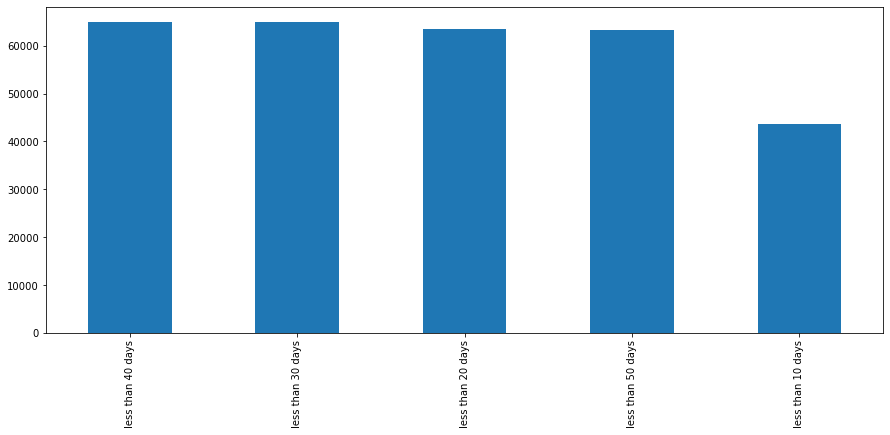

```python
fp['new_col'].value_counts().plot(kind='bar')
```

```
<function matplotlib.pyplot.tight_layout(*, pad=1.08, h_pad=None, w_pad=None, rect=None)>
```

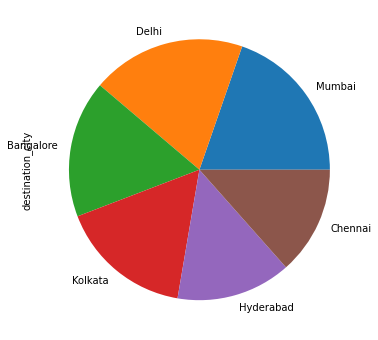

```python
fp['destination_city'].value_counts().plot(kind='pie')
plt.tight_layout
```

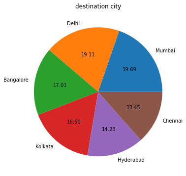

```python
plt.pie(fp['destination_city'].value_counts(),labels=['Mumbai','Delhi','Bangalore','Kolkata','Hyderabad','Chennai'],autopct='%.2f')
plt.title('destination city')
```

```python
## Repeating eda
df=pd.read_csv('Clean_Dataset.csv')
```

```python
df.head()
```

|  | Unnamed: 0 | airline | flight | source_city | departure_time | stops | arrival_time | destination_city | class | duration | days_left | price |
| --- | --- | --- | --- | --- | --- | --- | --- | --- | --- | --- | --- | --- |
| 0 | 0 | SpiceJet | SG-8709 | Delhi | Evening | zero | Night | Mumbai | Economy | 2.17 | 1 | 5953 |
| 1 | 1 | SpiceJet | SG-8157 | Delhi | Early_Morning | zero | Morning | Mumbai | Economy | 2.33 | 1 | 5953 |
| 2 | 2 | AirAsia | I5-764 | Delhi | Early_Morning | zero | Early_Morning | Mumbai | Economy | 2.17 | 1 | 5956 |
| 3 | 3 | Vistara | UK-995 | Delhi | Morning | zero | Afternoon | Mumbai | Economy | 2.25 | 1 | 5955 |
| 4 | 4 | Vistara | UK-963 | Delhi | Morning | zero | Morning | Mumbai | Economy | 2.33 | 1 | 5955 |

```python
df['flight'].nunique()
```

```
1561
```

```python
df.drop(['Unnamed: 0','flight'],axis=1,inplace=True)
```

```python
df.head()
```

|  | airline | source_city | departure_time | stops | arrival_time | destination_city | class | duration | days_left | price |
| --- | --- | --- | --- | --- | --- | --- | --- | --- | --- | --- |
| 0 | SpiceJet | Delhi | Evening | zero | Night | Mumbai | Economy | 2.17 | 1 | 5953 |
| 1 | SpiceJet | Delhi | Early_Morning | zero | Morning | Mumbai | Economy | 2.33 | 1 | 5953 |
| 2 | AirAsia | Delhi | Early_Morning | zero | Early_Morning | Mumbai | Economy | 2.17 | 1 | 5956 |
| 3 | Vistara | Delhi | Morning | zero | Afternoon | Mumbai | Economy | 2.25 | 1 | 5955 |
| 4 | Vistara | Delhi | Morning | zero | Morning | Mumbai | Economy | 2.33 | 1 | 5955 |

```python
df.head()
```

|  | airline | source_city | departure_time | stops | arrival_time | destination_city | class | duration | days_left | price |
| --- | --- | --- | --- | --- | --- | --- | --- | --- | --- | --- |
| 0 | SpiceJet | Delhi | Evening | zero | Night | Mumbai | Economy | 2.17 | 1 | 5953 |
| 1 | SpiceJet | Delhi | Early_Morning | zero | Morning | Mumbai | Economy | 2.33 | 1 | 5953 |
| 2 | AirAsia | Delhi | Early_Morning | zero | Early_Morning | Mumbai | Economy | 2.17 | 1 | 5956 |
| 3 | Vistara | Delhi | Morning | zero | Afternoon | Mumbai | Economy | 2.25 | 1 | 5955 |
| 4 | Vistara | Delhi | Morning | zero | Morning | Mumbai | Economy | 2.33 | 1 | 5955 |

```python
df['new_col']=df['days_left'].apply(day)
```

```python
df.drop('days_left',axis=1,inplace=True)
```

```python
df.head()
```

|  | airline | source_city | departure_time | stops | arrival_time | destination_city | class | duration | price | new_col |
| --- | --- | --- | --- | --- | --- | --- | --- | --- | --- | --- |
| 0 | SpiceJet | Delhi | Evening | zero | Night | Mumbai | Economy | 2.17 | 5953 | less than 10 days |
| 1 | SpiceJet | Delhi | Early_Morning | zero | Morning | Mumbai | Economy | 2.33 | 5953 | less than 10 days |
| 2 | AirAsia | Delhi | Early_Morning | zero | Early_Morning | Mumbai | Economy | 2.17 | 5956 | less than 10 days |
| 3 | Vistara | Delhi | Morning | zero | Afternoon | Mumbai | Economy | 2.25 | 5955 | less than 10 days |
| 4 | Vistara | Delhi | Morning | zero | Morning | Mumbai | Economy | 2.33 | 5955 | less than 10 days |

```python
df.isnull().sum()
```

```
airline             0
source_city         0
departure_time      0
stops               0
arrival_time        0
destination_city    0
class               0
duration            0
price               0
new_col             0
dtype: int64
```

```python
x=df.drop('price',axis=1)
y=df.price
```

```python
X=pd.get_dummies(x,drop_first=True)
```

```python
X.shape
```

```
(300153, 33)
```

# Eda

```python
fp.columns
```

```
Index(['airline', 'flight', 'source_city', 'departure_time', 'stops',
       'arrival_time', 'destination_city', 'class', 'duration', 'days_left',
       'price', 'new_col'],
      dtype='object')
```

```python
fp.head(1)
```

|  | airline | flight | source_city | departure_time | stops | arrival_time | destination_city | class | duration | days_left | price | new_col |
| --- | --- | --- | --- | --- | --- | --- | --- | --- | --- | --- | --- | --- |
| 0 | SpiceJet | SG-8709 | Delhi | Evening | zero | Night | Mumbai | Economy | 2.17 | 1 | 5953 | less than 10 days |

```python
fp.groupby('flight')['new_col'].transform('nunique')
```

```
0         5
1         5
2         5
3         5
4         5
         ..
300148    5
300149    5
300150    5
300151    5
300152    5
Name: new_col, Length: 300153, dtype: int64
```

```python
fp['flight and daysleft']=fp.groupby('flight')['new_col'].transform('nunique')
```

```python
fp.corr()
```

|  | duration | days_left | price | flight and daysleft |
| --- | --- | --- | --- | --- |
| duration | 1.000000 | -0.039157 | 0.204222 | 0.110063 |
| days_left | -0.039157 | 1.000000 | -0.091949 | -0.136941 |
| price | 0.204222 | -0.091949 | 1.000000 | 0.131896 |
| flight and daysleft | 0.110063 | -0.136941 | 0.131896 | 1.000000 |

```python
fp['airline and daysleft']=fp.groupby('airline')['new_col'].transform('nunique')
```

```python
fp.drop('airline and daysleft',axis=1,inplace=True)
```

```python
fp.corr()
```

|  | duration | days_left | price | flight and daysleft |
| --- | --- | --- | --- | --- |
| duration | 1.000000 | -0.039157 | 0.204222 | 0.110063 |
| days_left | -0.039157 | 1.000000 | -0.091949 | -0.136941 |
| price | 0.204222 | -0.091949 | 1.000000 | 0.131896 |
| flight and daysleft | 0.110063 | -0.136941 | 0.131896 | 1.000000 |

```python
fp['flight and duration']=fp.groupby('flight')['duration'].transform('nunique')
```

```python
fp.corr()
```

|  | duration | days_left | price | flight and daysleft | flight and duration |
| --- | --- | --- | --- | --- | --- |
| duration | 1.000000 | -0.039157 | 0.204222 | 0.110063 | 0.319660 |
| days_left | -0.039157 | 1.000000 | -0.091949 | -0.136941 | -0.022485 |
| price | 0.204222 | -0.091949 | 1.000000 | 0.131896 | 0.335084 |
| flight and daysleft | 0.110063 | -0.136941 | 0.131896 | 1.000000 | 0.216391 |
| flight and duration | 0.319660 | -0.022485 | 0.335084 | 0.216391 | 1.000000 |

```python
fp['mean flight and duration']=fp.groupby('flight')['duration'].transform('mean')
```

```python
fp['median flight and duration']=fp.groupby('flight')['duration'].transform('median')
fp['std flight and duration']=fp.groupby('flight')['duration'].transform('std')
```

```python
fp.corr()
```

|  | duration | days_left | price | flight and daysleft | flight and duration | mean flight and duration | median flight and duration | std flight and duration |
| --- | --- | --- | --- | --- | --- | --- | --- | --- |
| duration | 1.000000 | -0.039157 | 0.204222 | 0.110063 | 0.319660 | 0.600109 | 0.560827 | 0.400696 |
| days_left | -0.039157 | 1.000000 | -0.091949 | -0.136941 | -0.022485 | -0.027272 | -0.024676 | -0.024084 |
| price | 0.204222 | -0.091949 | 1.000000 | 0.131896 | 0.335084 | 0.297384 | 0.249207 | 0.267855 |
| flight and daysleft | 0.110063 | -0.136941 | 0.131896 | 1.000000 | 0.216391 | 0.183405 | 0.158456 | 0.209320 |
| flight and duration | 0.319660 | -0.022485 | 0.335084 | 0.216391 | 1.000000 | 0.532669 | 0.443994 | 0.489295 |
| mean flight and duration | 0.600109 | -0.027272 | 0.297384 | 0.183405 | 0.532669 | 1.000000 | 0.934542 | 0.667741 |
| median flight and duration | 0.560827 | -0.024676 | 0.249207 | 0.158456 | 0.443994 | 0.934542 | 1.000000 | 0.581953 |
| std flight and duration | 0.400696 | -0.024084 | 0.267855 | 0.209320 | 0.489295 | 0.667741 | 0.581953 | 1.000000 |

```python
fp.head()
```

|  | airline | flight | source_city | departure_time | stops | arrival_time | destination_city | class | duration | days_left | price | new_col | flight and daysleft | flight and duration | mean flight and duration | median flight and duration | std flight and duration |
| --- | --- | --- | --- | --- | --- | --- | --- | --- | --- | --- | --- | --- | --- | --- | --- | --- | --- |
| 0 | SpiceJet | SG-8709 | Delhi | Evening | zero | Night | Mumbai | Economy | 2.17 | 1 | 5953 | less than 10 days | 5 | 6 | 13.573609 | 13.08 | 10.126619 |
| 1 | SpiceJet | SG-8157 | Delhi | Early_Morning | zero | Morning | Mumbai | Economy | 2.33 | 1 | 5953 | less than 10 days | 5 | 4 | 14.251908 | 15.00 | 9.561908 |
| 2 | AirAsia | I5-764 | Delhi | Early_Morning | zero | Early_Morning | Mumbai | Economy | 2.17 | 1 | 5956 | less than 10 days | 5 | 2 | 6.250000 | 6.25 | 4.100977 |
| 3 | Vistara | UK-995 | Delhi | Morning | zero | Afternoon | Mumbai | Economy | 2.25 | 1 | 5955 | less than 10 days | 5 | 15 | 10.471875 | 9.58 | 5.042831 |
| 4 | Vistara | UK-963 | Delhi | Morning | zero | Morning | Mumbai | Economy | 2.33 | 1 | 5955 | less than 10 days | 5 | 15 | 11.770912 | 11.08 | 5.385288 |

```python
fp.loc[fp['std flight and duration'].isnull(),'std flight and duration']=fp['std flight and duration'].median()
```

# Statistical Test for Impact on Price by Numerical Columns

## Checking for Normality of Data.

- As we have a very large no. of records, we prefer to use Jarque-Bera Test for testing whether the data are drawn from normally distributed populations. ### Jarque Bera Test
- Null Hypothesis : Data is Normally distributed.
- Alternate Hypothesis : Data is not Normally distributed.

```python
fp_num = fp.select_dtypes(include = np.number).columns
fp_num
```

```
Index(['duration', 'days_left', 'price', 'flight and daysleft',
       'flight and duration', 'mean flight and duration',
       'median flight and duration', 'std flight and duration'],
      dtype='object')
```

```python
for i in fp_num:
    print( i, ':' ,stats.jarque_bera(fp[i].dropna()))
```

```
duration : Jarque_beraResult(statistic=19088.506175155922, pvalue=0.0)
days_left : Jarque_beraResult(statistic=16781.866981047817, pvalue=0.0)
price : Jarque_beraResult(statistic=58318.4796019082, pvalue=0.0)
flight and daysleft : Jarque_beraResult(statistic=22694934.353659287, pvalue=0.0)
flight and duration : Jarque_beraResult(statistic=22043.380628761188, pvalue=0.0)
mean flight and duration : Jarque_beraResult(statistic=59.67632935959663, pvalue=1.1002310174035301e-13)
median flight and duration : Jarque_beraResult(statistic=3526.8383552199234, pvalue=0.0)
std flight and duration : Jarque_beraResult(statistic=12004.325876335335, pvalue=0.0)
```

- As p_values for all features are less than significance levels of 0.05, we reject the null hypothesis that the data are drawn from normal populations.
- Now let us do both Pearson- R and Spearman Rank Correlation tests to validate the significance of the independent variables with the target feature -price.

### Pearson - r Correlation Test.

This test calculates the pearson-r correlation coefficient between the given samples and then does a t-test to assume any statistcally significant correlation between the populations.

- Null Hypothesis : pearson-r coefficient = 0 and there is no correaltion between the populations of the 2 features.
- Alternate Hypothesis : pearson-r coefficient is <> 0 and there is a correaltion between the popilations of the 2 features.

```python
for i in fp_num:
    print(i, ':', stats.pearsonr(fp[i], fp['price']))
```

```
duration : (0.20422236784542724, 0.0)
days_left : (-0.09194853217143853, 0.0)
price : (1.0, 0.0)
flight and daysleft : (0.13189625439654185, 0.0)
flight and duration : (0.33508410543996386, 0.0)
mean flight and duration : (0.29738383352964837, 0.0)
median flight and duration : (0.2492066920612799, 0.0)
std flight and duration : (0.26784431920312973, 0.0)
```

- As p-values values of all features are less than 0.05, the null hypothesis is rejected and hence there is a statistically significant correlation between the predictors and target.

### Spearman Rank Correlation Test.

- This test takes the correlation of the ranks of the data points in each sample thus makeing the test robust to outliers and reduces the sensitivity to the nature of distribution of data.
- Null Hypothesis : There is no correaltion between the populations of the 2 features.
- Alternate Hypothesis : There is a correaltion between the popilations of the 2 features.

```python
for i in fp_num:
    print(i, ':', stats.spearmanr(fp[i], fp['price']))
```

```
duration : SpearmanrResult(correlation=0.31884122663345993, pvalue=0.0)
days_left : SpearmanrResult(correlation=-0.26701898446039224, pvalue=0.0)
price : SpearmanrResult(correlation=0.9999999999999998, pvalue=0.0)
flight and daysleft : SpearmanrResult(correlation=0.22629727127936625, pvalue=0.0)
flight and duration : SpearmanrResult(correlation=0.42098236173814496, pvalue=0.0)
mean flight and duration : SpearmanrResult(correlation=0.37545750717440696, pvalue=0.0)
median flight and duration : SpearmanrResult(correlation=0.32721987489222004, pvalue=0.0)
std flight and duration : SpearmanrResult(correlation=0.3030232837814359, pvalue=0.0)
```

```python
fp_cat = fp.select_dtypes(exclude = np.number)
fp_cat
```

|  | airline | flight | source_city | departure_time | stops | arrival_time | destination_city | class | new_col |
| --- | --- | --- | --- | --- | --- | --- | --- | --- | --- |
| 0 | SpiceJet | SG-8709 | Delhi | Evening | zero | Night | Mumbai | Economy | less than 10 days |
| 1 | SpiceJet | SG-8157 | Delhi | Early_Morning | zero | Morning | Mumbai | Economy | less than 10 days |
| 2 | AirAsia | I5-764 | Delhi | Early_Morning | zero | Early_Morning | Mumbai | Economy | less than 10 days |
| 3 | Vistara | UK-995 | Delhi | Morning | zero | Afternoon | Mumbai | Economy | less than 10 days |
| 4 | Vistara | UK-963 | Delhi | Morning | zero | Morning | Mumbai | Economy | less than 10 days |
| ... | ... | ... | ... | ... | ... | ... | ... | ... | ... |
| 300148 | Vistara | UK-822 | Chennai | Morning | one | Evening | Hyderabad | Business | less than 50 days |
| 300149 | Vistara | UK-826 | Chennai | Afternoon | one | Night | Hyderabad | Business | less than 50 days |
| 300150 | Vistara | UK-832 | Chennai | Early_Morning | one | Night | Hyderabad | Business | less than 50 days |
| 300151 | Vistara | UK-828 | Chennai | Early_Morning | one | Evening | Hyderabad | Business | less than 50 days |
| 300152 | Vistara | UK-822 | Chennai | Morning | one | Evening | Hyderabad | Business | less than 50 days |

300153 rows × 9 columns

```python
fp_cat.drop('flight', axis = 1, inplace = True)
```

```python
fp_cat_multi = fp[fp_cat.columns[fp_cat.nunique() > 2]]
fp_cat_multi['price'] = fp['price']
fp_cat_multi
```

|  | airline | source_city | departure_time | stops | arrival_time | destination_city | new_col | price |
| --- | --- | --- | --- | --- | --- | --- | --- | --- |
| 0 | SpiceJet | Delhi | Evening | zero | Night | Mumbai | less than 10 days | 5953 |
| 1 | SpiceJet | Delhi | Early_Morning | zero | Morning | Mumbai | less than 10 days | 5953 |
| 2 | AirAsia | Delhi | Early_Morning | zero | Early_Morning | Mumbai | less than 10 days | 5956 |
| 3 | Vistara | Delhi | Morning | zero | Afternoon | Mumbai | less than 10 days | 5955 |
| 4 | Vistara | Delhi | Morning | zero | Morning | Mumbai | less than 10 days | 5955 |
| ... | ... | ... | ... | ... | ... | ... | ... | ... |
| 300148 | Vistara | Chennai | Morning | one | Evening | Hyderabad | less than 50 days | 69265 |
| 300149 | Vistara | Chennai | Afternoon | one | Night | Hyderabad | less than 50 days | 77105 |
| 300150 | Vistara | Chennai | Early_Morning | one | Night | Hyderabad | less than 50 days | 79099 |
| 300151 | Vistara | Chennai | Early_Morning | one | Evening | Hyderabad | less than 50 days | 81585 |
| 300152 | Vistara | Chennai | Morning | one | Evening | Hyderabad | less than 50 days | 81585 |

300153 rows × 8 columns

# Statsitical Tests for Impact on Price by Categorical Columns.

### Kruskal -Wallis Test

- This test is a non-parametric variant of f-oneway anova that does not require the assumptions of normality and heteroskedasticity of data.
- This test uses the rank sums as the central tendency which makes it robust to the outliers and nature of distribution of data.
- As our data is not normal, we proceed forward with this non- parametric test.

```python
airline = fp_cat_multi.groupby('airline')
stats.kruskal(airline.get_group('SpiceJet')['price'],
             airline.get_group('AirAsia')['price'],
             airline.get_group('Vistara')['price'],
             airline.get_group('GO_FIRST')['price'],
             airline.get_group('Indigo')['price'],
             airline.get_group('Air_India')['price'])
```

```
KruskalResult(statistic=94612.80508823595, pvalue=0.0)
```

```python
s_city = fp_cat_multi.groupby('source_city')
stats.kruskal(s_city.get_group('Delhi')['price'],
             s_city.get_group('Mumbai')['price'],
             s_city.get_group('Bangalore')['price'],
             s_city.get_group('Kolkata')['price'],
             s_city.get_group('Hyderabad')['price'],
             s_city.get_group('Chennai')['price'])
```

```
KruskalResult(statistic=1854.943025414105, pvalue=0.0)
```

```python
d_time = fp_cat_multi.groupby('departure_time')
stats.kruskal(d_time.get_group('Evening')['price'],
             d_time.get_group('Early_Morning')['price'],
             d_time.get_group('Morning')['price'],
             d_time.get_group('Afternoon')['price'],
             d_time.get_group('Night')['price'],
             d_time.get_group('Late_Night')['price'])
```

```
KruskalResult(statistic=1873.431331033466, pvalue=0.0)
```

```python
a_time = fp_cat_multi.groupby('arrival_time')
stats.kruskal(a_time.get_group('Evening')['price'],
             a_time.get_group('Early_Morning')['price'],
             a_time.get_group('Morning')['price'],
             a_time.get_group('Afternoon')['price'],
             a_time.get_group('Night')['price'],
             a_time.get_group('Late_Night')['price'])
```

```
KruskalResult(statistic=9027.839997220486, pvalue=0.0)
```

```python
d_city = fp_cat_multi.groupby('destination_city')
stats.kruskal(d_city.get_group('Delhi')['price'],
             d_city.get_group('Mumbai')['price'],
             d_city.get_group('Bangalore')['price'],
             d_city.get_group('Kolkata')['price'],
             d_city.get_group('Hyderabad')['price'],
             d_city.get_group('Chennai')['price'])
```

```
KruskalResult(statistic=1603.3889486461671, pvalue=0.0)
```

```python
stops = fp_cat_multi.groupby('stops')
stats.kruskal(stops.get_group('zero')['price'],
             stops.get_group('one')['price'],
             stops.get_group('two_or_more')['price'])
```

```
KruskalResult(statistic=20484.29943114362, pvalue=0.0)
```

```python
new_c = fp_cat_multi.groupby('new_col')
stats.kruskal(new_c.get_group('less than 10 days')['price'],
             new_c.get_group('less than 20 days')['price'],
             new_c.get_group('less than 30 days')['price'],
             new_c.get_group('less than 40 days')['price'],
             new_c.get_group('less than 50 days')['price'])
```

```
KruskalResult(statistic=24996.789833231724, pvalue=0.0)
```

- As p-value for all categories are less than the significant level of 0.05, we reject the null hypothesis and conclude that not all the sub-categories have the same rank sums.
- This shows that all the categories above has a statistically significant influence on the target - price.

### Mann Whitney - U Test.

- As our target variable price is not drawn from a normal population, we use a non-parametric test call Mann-Whitney -U or Wilcoxon- Rank-Sum Test to determine the statistical signifiance of a binary categorical classification of a continuous numerical variable.
- Null Hypotheis - The rank sums for both classes are same. There is no impact of the category on numerical variable.
- Alternate Hypotheis - The rank sums for both classes are different. There is a significant impact of category on numerical variable.

```python
stats.mannwhitneyu(fp[fp['class'] == 'Economy']['price'],
                   fp[fp['class'] == 'Business']['price'])
```

```
MannwhitneyuResult(statistic=6234631.5, pvalue=0.0)
```

- As the p-value is less than the significant levl of 0.05, we reject the null hypothesis that there is no dependence between class and price.
- The class category has a statistically significant impact on the price variable.

```python
X=fp.drop(['price','flight'],axis=1)
y=fp.price
```

```python
XX=pd.get_dummies(X,drop_first=True)
```

```python
from sklearn.model_selection import train_test_split

xtrain,xtest,ytrain,ytest=train_test_split(XX,y,test_size=0.3,random_state=69)

import statsmodels.api as sma
```

```python
fp.head()
```

|  | airline | flight | source_city | departure_time | stops | arrival_time | destination_city | class | duration | days_left | price | new_col | flight and daysleft | flight and duration | mean flight and duration | median flight and duration | std flight and duration |
| --- | --- | --- | --- | --- | --- | --- | --- | --- | --- | --- | --- | --- | --- | --- | --- | --- | --- |
| 0 | SpiceJet | SG-8709 | Delhi | Evening | zero | Night | Mumbai | Economy | 2.17 | 1 | 5953 | less than 10 days | 5 | 6 | 13.573609 | 13.08 | 10.126619 |
| 1 | SpiceJet | SG-8157 | Delhi | Early_Morning | zero | Morning | Mumbai | Economy | 2.33 | 1 | 5953 | less than 10 days | 5 | 4 | 14.251908 | 15.00 | 9.561908 |
| 2 | AirAsia | I5-764 | Delhi | Early_Morning | zero | Early_Morning | Mumbai | Economy | 2.17 | 1 | 5956 | less than 10 days | 5 | 2 | 6.250000 | 6.25 | 4.100977 |
| 3 | Vistara | UK-995 | Delhi | Morning | zero | Afternoon | Mumbai | Economy | 2.25 | 1 | 5955 | less than 10 days | 5 | 15 | 10.471875 | 9.58 | 5.042831 |
| 4 | Vistara | UK-963 | Delhi | Morning | zero | Morning | Mumbai | Economy | 2.33 | 1 | 5955 | less than 10 days | 5 | 15 | 11.770912 | 11.08 | 5.385288 |

```python
fp.dtypes
```

```
airline                        object
flight                         object
source_city                    object
departure_time                 object
stops                          object
arrival_time                   object
destination_city               object
class                          object
duration                      float64
days_left                       int64
price                           int64
new_col                        object
flight and daysleft             int64
flight and duration             int64
mean flight and duration      float64
median flight and duration    float64
std flight and duration       float64
dtype: object
```

```python
XX.isnull().sum()
```

```
duration                        0
days_left                       0
flight and daysleft             0
flight and duration             0
mean flight and duration        0
median flight and duration      0
std flight and duration         0
airline_Air_India               0
airline_GO_FIRST                0
airline_Indigo                  0
airline_SpiceJet                0
airline_Vistara                 0
source_city_Chennai             0
source_city_Delhi               0
source_city_Hyderabad           0
source_city_Kolkata             0
source_city_Mumbai              0
departure_time_Early_Morning    0
departure_time_Evening          0
departure_time_Late_Night       0
departure_time_Morning          0
departure_time_Night            0
stops_two_or_more               0
stops_zero                      0
arrival_time_Early_Morning      0
arrival_time_Evening            0
arrival_time_Late_Night         0
arrival_time_Morning            0
arrival_time_Night              0
destination_city_Chennai        0
destination_city_Delhi          0
destination_city_Hyderabad      0
destination_city_Kolkata        0
destination_city_Mumbai         0
class_Economy                   0
new_col_less than 20 days       0
new_col_less than 30 days       0
new_col_less than 40 days       0
new_col_less than 50 days       0
dtype: int64
```

```python
fp.isnull().sum()
```

```
airline                       0
flight                        0
source_city                   0
departure_time                0
stops                         0
arrival_time                  0
destination_city              0
class                         0
duration                      0
days_left                     0
price                         0
new_col                       0
flight and daysleft           0
flight and duration           0
mean flight and duration      0
median flight and duration    0
std flight and duration       0
dtype: int64
```

```python
XX.shape
```

```
(300153, 39)
```

```python
#new stats model
```

```python
model=sma.OLS(ytrain,xtrain).fit()
```

```python
model.summary()
```

OLS Regression Results

| Dep. Variable: | price | R-squared (uncentered): | 0.936 |
| --- | --- | --- | --- |
| Model: | OLS | Adj. R-squared (uncentered): | 0.936 |
| Method: | Least Squares | F-statistic: | 7.815e+04 |
| Date: | Thu, 22 Dec 2022 | Prob (F-statistic): | 0.00 |
| Time: | 10:32:34 | Log-Likelihood: | -2.1820e+06 |
| No. Observations: | 210107 | AIC: | 4.364e+06 |
| Df Residuals: | 210068 | BIC: | 4.365e+06 |
| Df Model: | 39 |  |  |
| Covariance Type: | nonrobust |  |  |

|  | coef | std err | t | P>\|t\| | [0.025 | 0.975] |
| --- | --- | --- | --- | --- | --- | --- |
| duration | 108.3273 | 3.453 | 31.376 | 0.000 | 101.560 | 115.094 |
| days_left | 127.3682 | 5.975 | 21.318 | 0.000 | 115.658 | 139.079 |
| flight and daysleft | 6616.0520 | 24.010 | 275.559 | 0.000 | 6568.994 | 6663.110 |
| flight and duration | 50.9585 | 1.725 | 29.533 | 0.000 | 47.577 | 54.340 |
| mean flight and duration | 284.6451 | 14.099 | 20.189 | 0.000 | 257.012 | 312.278 |
| median flight and duration | -123.1334 | 11.278 | -10.918 | 0.000 | -145.239 | -101.028 |
| std flight and duration | -161.3969 | 12.833 | -12.577 | 0.000 | -186.549 | -136.245 |
| airline_Air_India | 4357.5207 | 106.327 | 40.982 | 0.000 | 4149.123 | 4565.919 |
| airline_GO_FIRST | 9670.5155 | 92.538 | 104.504 | 0.000 | 9489.144 | 9851.887 |
| airline_Indigo | 9547.9399 | 86.627 | 110.219 | 0.000 | 9378.153 | 9717.727 |
| airline_SpiceJet | 8617.4300 | 130.127 | 66.223 | 0.000 | 8362.384 | 8872.476 |
| airline_Vistara | 8431.8334 | 95.780 | 88.033 | 0.000 | 8244.106 | 8619.561 |
| source_city_Chennai | 1289.0564 | 67.845 | 19.000 | 0.000 | 1156.083 | 1422.030 |
| source_city_Delhi | 2119.5819 | 61.755 | 34.323 | 0.000 | 1998.544 | 2240.620 |
| source_city_Hyderabad | 430.2544 | 63.922 | 6.731 | 0.000 | 304.969 | 555.540 |
| source_city_Kolkata | 3193.6807 | 62.868 | 50.800 | 0.000 | 3070.461 | 3316.901 |
| source_city_Mumbai | 2489.0886 | 58.163 | 42.795 | 0.000 | 2375.090 | 2603.087 |
| departure_time_Early_Morning | 3115.2529 | 57.032 | 54.623 | 0.000 | 3003.472 | 3227.034 |
| departure_time_Evening | 2280.5652 | 60.238 | 37.860 | 0.000 | 2162.501 | 2398.629 |
| departure_time_Late_Night | 6732.3551 | 265.390 | 25.368 | 0.000 | 6212.198 | 7252.512 |
| departure_time_Morning | 2669.6017 | 55.700 | 47.929 | 0.000 | 2560.432 | 2778.772 |
| departure_time_Night | 2643.7974 | 64.886 | 40.745 | 0.000 | 2516.622 | 2770.972 |
| stops_two_or_more | 3137.4165 | 86.052 | 36.460 | 0.000 | 2968.757 | 3306.076 |
| stops_zero | -6133.9614 | 63.576 | -96.483 | 0.000 | -6258.568 | -6009.355 |
| arrival_time_Early_Morning | 2491.9467 | 91.907 | 27.114 | 0.000 | 2311.811 | 2672.083 |
| arrival_time_Evening | 3596.4131 | 58.404 | 61.578 | 0.000 | 3481.942 | 3710.884 |
| arrival_time_Late_Night | 5679.8292 | 95.390 | 59.543 | 0.000 | 5492.868 | 5866.791 |
| arrival_time_Morning | 3114.1752 | 61.745 | 50.436 | 0.000 | 2993.157 | 3235.194 |
| arrival_time_Night | 4139.6232 | 57.124 | 72.468 | 0.000 | 4027.662 | 4251.584 |
| destination_city_Chennai | 1692.7177 | 63.283 | 26.748 | 0.000 | 1568.684 | 1816.751 |
| destination_city_Delhi | 1605.0665 | 59.487 | 26.982 | 0.000 | 1488.474 | 1721.659 |
| destination_city_Hyderabad | 533.0748 | 62.453 | 8.536 | 0.000 | 410.669 | 655.481 |
| destination_city_Kolkata | 3606.4086 | 60.306 | 59.802 | 0.000 | 3488.210 | 3724.607 |
| destination_city_Mumbai | 2262.1431 | 58.090 | 38.942 | 0.000 | 2148.287 | 2375.999 |
| class_Economy | -4.308e+04 | 41.158 | -1046.813 | 0.000 | -4.32e+04 | -4.3e+04 |
| new_col_less than 20 days | -2065.9250 | 80.252 | -25.743 | 0.000 | -2223.216 | -1908.634 |
| new_col_less than 30 days | -5344.4305 | 128.807 | -41.492 | 0.000 | -5596.889 | -5091.972 |
| new_col_less than 40 days | -6807.5554 | 184.230 | -36.951 | 0.000 | -7168.642 | -6446.469 |
| new_col_less than 50 days | -6976.7261 | 241.722 | -28.863 | 0.000 | -7450.495 | -6502.958 |

| Omnibus: | 33349.476 | Durbin-Watson: | 2.001 |
| --- | --- | --- | --- |
| Prob(Omnibus): | 0.000 | Jarque-Bera (JB): | 118763.301 |
| Skew: | 0.785 | Prob(JB): | 0.00 |
| Kurtosis: | 6.332 | Cond. No. | 869. |

Notes:  
[1] R² is computed without centering (uncentered) since the model does not contain a constant.  
[2] Standard Errors assume that the covariance matrix of the errors is correctly specified.

```python
model.aic
```

```
4364117.714777948
```

```python
from sklearn.model_selection import cross_val_score,KFold
```

```python
# new decision tree model
```

```python
from sklearn.tree import DecisionTreeRegressor
```

```python
dt=DecisionTreeRegressor()
dt.fit(xtrain,ytrain)
```

```
DecisionTreeRegressor()
```

```python
pred_new_dt=dt.predict(xtest)
```

```python
pred_new_tr_dt=dt.predict(xtrain)
```

```python
np.mean(r2_score(ytest,pred_new_dt))
```

```
0.9831748320255446
```

```python
np.mean(r2_score(ytrain,pred_new_tr_dt))
```

```
0.9999072412607735
```

```python
(mean_squared_error(ytest,pred_new_dt))
```

```
8687152.656620566
```

```python
(mean_squared_error(ytrain,pred_new_tr_dt))
```

```
47742.93570498208
```

```python
mean_absolute_percentage_error(ytest,pred_new_dt)
```

```
0.058533714530857574
```

```python
mean_absolute_percentage_error(ytrain,pred_new_tr_dt)
```

```
0.00042512709753364834
```

# Hyper parameter tuning for dt

```python
from sklearn.model_selection import GridSearchCV
```

```python
params={'max_depth':[4,6,8,10],'min_samples_split':[2,4,6],'min_samples_leaf':[1,2,3]}
```

```python
grid=GridSearchCV(estimator=dt,param_grid=params)
```

```python
grid.fit(xtrain,ytrain)
```

```
GridSearchCV(estimator=DecisionTreeRegressor(),
             param_grid={'max_depth': [4, 6, 8, 10],
                         'min_samples_leaf': [1, 2, 3],
                         'min_samples_split': [2, 4, 6]})
```

```python
grid.best_params_
```

```
{'max_depth': 10, 'min_samples_leaf': 1, 'min_samples_split': 4}
```

```python
dt_tu=DecisionTreeRegressor(max_depth=10,min_samples_leaf=1,min_samples_split=4)
```

```python
dt_tu.fit(xtrain,ytrain)
```

```
DecisionTreeRegressor(max_depth=10, min_samples_split=4)
```

```python
pred_new_dt_tu=dt_tu.predict(xtest)
```

```python
pred_new_tr_dt_tu=dt_tu.predict(xtrain)
```

```python
np.sqrt(mean_squared_error(ytrain,pred_new_tr_dt_tu))
```

```
4144.949834407033
```

```python
np.sqrt(mean_squared_error(ytest,pred_new_dt_tu))
```

```
4169.425569665161
```

```python
dt_tu.feature_importances_
```

```
array([4.28867731e-02, 1.10726603e-02, 1.11846383e-05, 5.47350890e-03,
       9.31037200e-04, 5.45940195e-04, 6.41752272e-03, 9.18934322e-03,
       1.34877261e-04, 8.77661574e-05, 1.60722590e-04, 9.65038207e-04,
       1.40549817e-04, 7.49951274e-04, 1.58324835e-03, 1.18687730e-03,
       2.72547628e-04, 3.68621768e-06, 7.07630112e-04, 5.37928385e-09,
       1.21413570e-04, 9.45697712e-05, 2.40549246e-03, 4.08896760e-05,
       4.50919695e-08, 7.50882342e-05, 2.48367712e-06, 1.72473870e-05,
       3.07426710e-04, 6.32403061e-05, 9.93855579e-04, 1.63438688e-03,
       1.62468466e-03, 5.61357747e-04, 9.09534874e-01, 1.86147061e-06,
       2.06874676e-08, 1.11975447e-07, 7.99037696e-08])
```

# cross val score for dt

```python
kfold=KFold(n_splits=5,random_state=121,shuffle=True)
```

```python
dt_cross_val_score=np.mean(cross_val_score(dt,xtrain,ytrain,cv=kfold,n_jobs=-1))
```

```python
dt_cross_val_score
```

```
0.9820288719720462
```

```python
#new random forest
from sklearn.ensemble import RandomForestRegressor
```

```python
rf=RandomForestRegressor()
rf.fit(xtrain,ytrain)
pred_new_rf=rf.predict(xtest)
pred_new_tr_rf=rf.predict(xtrain)
print(np.mean(r2_score(ytest,pred_new_rf)))
print(np.mean(r2_score(ytrain,pred_new_tr_rf)))
```

```
0.9898965967809475
0.9985139343118976
```

```python
np.sqrt(mean_squared_error(ytest,pred_new_rf))
```

```
2283.982989860766
```

```python
np.sqrt(mean_squared_error(ytrain,pred_new_tr_rf))
```

```
874.5731598498577
```

# cross val score for rf

```python
kfold=KFold(n_splits=5,random_state=121,shuffle=True)
```

```python
cross_val_score_rf=np.mean(cross_val_score(rf,xtrain,ytrain,cv=kfold,n_jobs=-1))
```

```python
cross_val_score_rf
```

```
0.9890345324641819
```

# ADaboost

```python
from sklearn.ensemble import AdaBoostRegressor
```

```python
ada=AdaBoostRegressor()
ada.fit(xtrain,ytrain)
pred_new_ada=ada.predict(xtest)
pred_new_tr_ada=ada.predict(xtrain)
print(np.mean(r2_score(ytest,pred_new_ada)))
print(np.mean(r2_score(ytrain,pred_new_tr_ada)))
```

```
0.9314732269591858
0.9314505639866255
```

```python
np.sqrt(mean_squared_error(ytest,pred_new_ada))
```

```
5948.249309811603
```

```python
np.sqrt(mean_squared_error(ytrain,pred_new_tr_ada))
```

```
5939.899329628324
```

# cross val score for adaboost

```python
kfold=KFold(n_splits=5,random_state=121,shuffle=True)
```

```python
cross_val_score_ada=np.mean(cross_val_score(ada,xtrain,ytrain,cv=kfold,n_jobs=-1))
```

```python
cross_val_score_ada
```

```
0.9289991343787568
```

```python
from xgboost import XGBRegressor
```

```python
xgb=XGBRegressor()
xgb.fit(xtrain,ytrain)
pred_new_xgb=xgb.predict(xtest)
pred_new_tr_xgb=xgb.predict(xtrain)
print(np.mean(r2_score(ytest,pred_new_xgb)))
print(np.mean(r2_score(ytrain,pred_new_tr_xgb)))
```

```
0.9834855357257046
0.9847987375262006
```

```python
np.sqrt(mean_squared_error(ytest,pred_new_xgb))
```

```
2920.0565843629556
```

```python
np.sqrt(mean_squared_error(ytrain,pred_new_tr_xgb))
```

```
2797.1578189758416
```

```python
kfold=KFold(n_splits=5,random_state=121,shuffle=True)
```

```python
cross_val_score_xgb=np.mean(cross_val_score(xgb,xtrain,ytrain,cv=kfold,n_jobs=-1))
```

```python
cross_val_score_xgb
```

```
0.9834030597021372
```

# Parameter tuning for xgboost

```python
from sklearn.model_selection import GridSearchCV
```

```python
xgb=XGBRegressor()
params={'n_estimators':[10,20,30,40],'max_depth':[4,6,8,10],'learning_rate':[0.5,1,1.5]}
```

```python
grid_xgb=GridSearchCV(estimator=xgb,param_grid=params)
```

```python
grid_xgb.fit(xtrain,ytrain)
```

```
GridSearchCV(estimator=XGBRegressor(base_score=None, booster=None,
                                    callbacks=None, colsample_bylevel=None,
                                    colsample_bynode=None,
                                    colsample_bytree=None,
                                    early_stopping_rounds=None,
                                    enable_categorical=False, eval_metric=None,
                                    feature_types=None, gamma=None, gpu_id=None,
                                    grow_policy=None, importance_type=None,
                                    interaction_constraints=None,
                                    learning_rate=None, max_bin=None,
                                    max_cat_threshold=None,
                                    max_cat_to_onehot=None, max_delta_step=None,
                                    max_depth=None, max_leaves=None,
                                    min_child_weight=None, missing=nan,
                                    monotone_constraints=None, n_estimators=100,
                                    n_jobs=None, num_parallel_tree=None,
                                    predictor=None, random_state=None, ...),
             param_grid={'learning_rate': [0.5, 1, 1.5],
                         'max_depth': [4, 6, 8, 10],
                         'n_estimators': [10, 20, 30, 40]})
```

```python
grid_xgb.best_params_
```

```
{'learning_rate': 0.5, 'max_depth': 10, 'n_estimators': 40}
```

```python
xgb_tuned=XGBRegressor(max_depth=10,n_estimators=40,learning_rate=0.5)
```

```python
xgb_tuned.fit(xtrain,ytrain)
```

```
XGBRegressor(base_score=0.5, booster='gbtree', callbacks=None,
             colsample_bylevel=1, colsample_bynode=1, colsample_bytree=1,
             early_stopping_rounds=None, enable_categorical=False,
             eval_metric=None, feature_types=None, gamma=0, gpu_id=-1,
             grow_policy='depthwise', importance_type=None,
             interaction_constraints='', learning_rate=0.5, max_bin=256,
             max_cat_threshold=64, max_cat_to_onehot=4, max_delta_step=0,
             max_depth=10, max_leaves=0, min_child_weight=1, missing=nan,
             monotone_constraints='()', n_estimators=40, n_jobs=0,
             num_parallel_tree=1, predictor='auto', random_state=0, ...)
```

```python
pred_tr_xgb_tuned=xgb_tuned.predict(xtrain)
```

```python
pred_xgb_tuned=xgb_tuned.predict(xtest)
```

```python
np.mean(r2_score(ytrain,pred_tr_xgb_tuned))
```

```
0.994174802886741
```

```python
np.mean(r2_score(ytest,pred_xgb_tuned))
```

```
0.9901507432853328
```

```python
np.sqrt(mean_squared_error(ytrain,pred_tr_xgb_tuned))
```

```
1731.5397041484753
```

```python
np.sqrt(mean_squared_error(ytest,pred_xgb_tuned))
```

```
2255.0737566227167
```

```python
mean_squared_error(ytrain,pred_tr_xgb_tuned)
```

```
2998229.7470425894
```

```python
mean_squared_error(ytest,pred_xgb_tuned)
```

```
5085357.647808492
```

# cross val score

```python
from sklearn.model_selection import cross_val_score,KFold
```

```python
kfold=KFold(n_splits=5,random_state=121,shuffle=True)
```

```python
tuned_score=np.mean(cross_val_score(xgb_tuned,xtrain,ytrain,cv=kfold,scoring='r2',n_jobs=-1))
```

```python
tuned_score
```

```
0.9895110164895542
```

# Light GBM

```python
from lightgbm import LGBMRegressor
```

```python
lgb=LGBMRegressor()
lgb.fit(xtrain,ytrain)
```

```
LGBMRegressor()
```

```python
pred_tr_lgb=lgb.predict(xtrain)
pred_lgb=lgb.predict(xtest)
```

```python
np.mean(r2_score(ytrain,pred_tr_lgb))
```

```
0.9784731314249
```

```python
np.mean(r2_score(ytest,pred_lgb))
```

```
0.9777418199301389
```

```python
np.sqrt(mean_squared_error(ytrain,pred_tr_lgb))
```

```
3328.6456984116344
```

```python
np.sqrt(mean_squared_error(ytest,pred_lgb))
```

```
3390.0323930768122
```

# cross val score for lgbm

```python
from sklearn.model_selection import cross_val_score,KFold
```

```python
kfold=KFold(n_splits=5,random_state=121,shuffle=True)
```

```python
tuned_score=np.mean(cross_val_score(lgb,xtrain,ytrain,cv=kfold,scoring='r2',n_jobs=-1))
```

```python
tuned_score
```

```
0.9778950885716707
```

# Parameter tuning for lgbm

```python
params={'n_estimators':[50,100,150,200],'max_depth':[4,6,8,10],'learning_rate':[0.5,1,1.5]}
```

```python
grid=GridSearchCV(estimator=lgb,param_grid=params)
```

```python
grid.fit(xtrain,ytrain)
```

```
GridSearchCV(estimator=LGBMRegressor(),
             param_grid={'learning_rate': [0.5, 1, 1.5],
                         'max_depth': [4, 6, 8, 10],
                         'n_estimators': [50, 100, 150, 200]})
```

```python
grid.best_params_
```

```
{'learning_rate': 0.5, 'max_depth': 10, 'n_estimators': 200}
```

```python
lgbm_tuned=LGBMRegressor(n_estimators=200,learning_rate=0.5,max_depth=10)
```

```python
lgbm_tuned.fit(xtrain,ytrain)
```

```
LGBMRegressor(learning_rate=0.5, max_depth=10, n_estimators=200)
```

```python
lgbm_tr_tuned_pred=lgbm_tuned.predict(xtrain)
lgbm_tuned_pred=lgbm_tuned.predict(xtest)
```

```python
np.mean(r2_score(ytrain,lgbm_tr_tuned_pred))
```

```
0.9898795380174984
```

```python
np.mean(r2_score(ytest,lgbm_tuned_pred))
```

```
0.9878030961221237
```

```python
np.sqrt(mean_squared_error(ytrain,lgbm_tr_tuned_pred))
```

```
2282.3240698585914
```

```python
np.sqrt(mean_squared_error(ytest,lgbm_tuned_pred))
```

```
2509.4804859778433
```

# cv using tuned lgbm

```python
kfold=KFold(n_splits=5,random_state=121,shuffle=True)
```

```python
tuned_score=np.mean(cross_val_score(lgbm_tuned,xtrain,ytrain,cv=kfold,scoring='r2',n_jobs=-1))
```

```python
tuned_score
```

```
0.9874311607033259
```

# Dataframe of cross val score

```python
kfold=KFold(n_splits=10,random_state=121,shuffle=True)
```

```python
sc_dt=cross_val_score(dt,xtrain,ytrain,cv=kfold,n_jobs=-1,scoring='neg_root_mean_squared_error')
```

```python
sc_rf=cross_val_score(rf,xtrain,ytrain,cv=kfold,n_jobs=-1,scoring='neg_root_mean_squared_error')
```

```python
sc_ada=cross_val_score(ada,xtrain,ytrain,cv=kfold,n_jobs=-1,scoring='neg_root_mean_squared_error')
```

```python
sc_xgb=cross_val_score(xgb,xtrain,ytrain,cv=kfold,n_jobs=-1,scoring='neg_root_mean_squared_error')
```

```python
sc_lgb=cross_val_score(lgb,xtrain,ytrain,cv=kfold,n_jobs=-1,scoring='neg_root_mean_squared_error')
```

```python
scores=pd.DataFrame({'decision_Tree':sc_dt,
              'random_forest':sc_rf,
             'adaboost':sc_ada,
             'xgb':sc_xgb,
             'lGBM':sc_lgb})
```

```python
scores
```

|  | decision_Tree | random_forest | adaboost | xgb | lGBM |
| --- | --- | --- | --- | --- | --- |
| 0 | -2960.647172 | -2341.939520 | -5882.849055 | -2909.353083 | -3372.152396 |
| 1 | -2987.409920 | -2307.475042 | -6767.522362 | -2883.980759 | -3339.464942 |
| 2 | -2961.322051 | -2318.997887 | -6582.145512 | -2958.402300 | -3415.667226 |
| 3 | -2859.996087 | -2285.544657 | -6120.867565 | -2862.615557 | -3315.264205 |
| 4 | -3055.129281 | -2420.448828 | -5813.511237 | -2901.718736 | -3407.452718 |
| 5 | -3017.654587 | -2366.814669 | -6155.344420 | -2867.367244 | -3328.377334 |
| 6 | -2899.054563 | -2366.100175 | -6018.212905 | -2956.566500 | -3423.944635 |
| 7 | -2867.023954 | -2287.017052 | -5750.611776 | -2892.751961 | -3349.732391 |
| 8 | -2953.818698 | -2317.392947 | -5725.840663 | -2892.452791 | -3363.891033 |
| 9 | -2966.492461 | -2358.547252 | -6549.637651 | -2952.983237 | -3427.177897 |

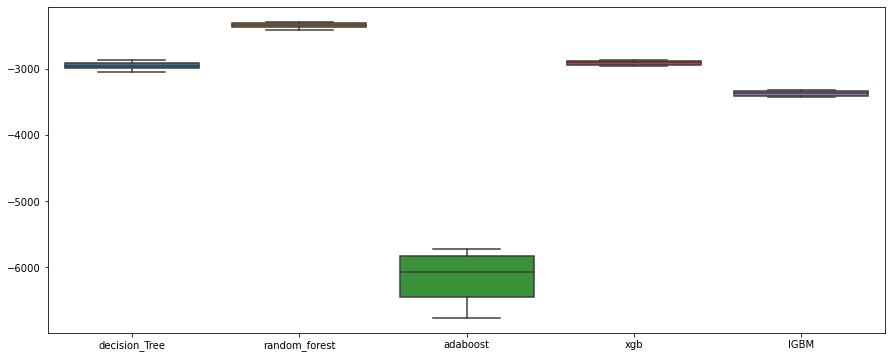

```python
sns.boxplot(data=scores)
```